# ONLINE PAYMENT FRAUD DETECTION USING MACHINE LEARNING

## RESULTS

### 1.PRESENTATION OF DATA

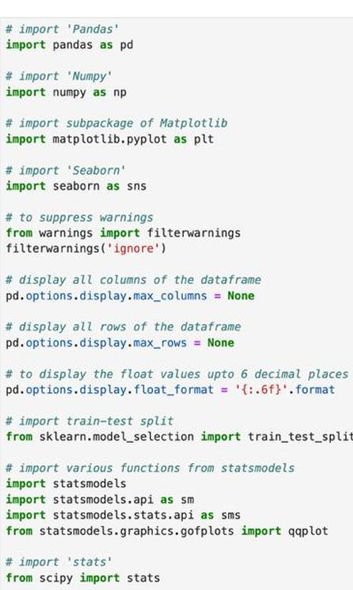

The libraries used are :

Pandas: This library helps to load the data frame in a 2D array format and has multiple functions to perform analysis tasks in one go. Seaborn/Matplotlib: For data visualization. Numpy: Numpy arrays are very fast and can perform large computations in a very short time.

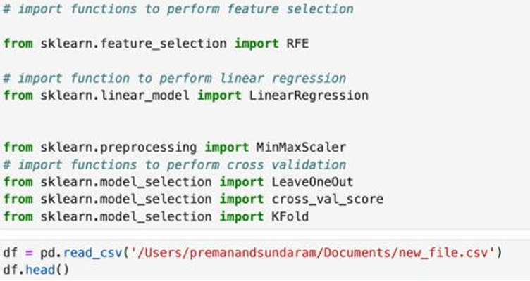

The dataset includes the features like type of payment, Old balance , amount paid, name of the destination, etc.

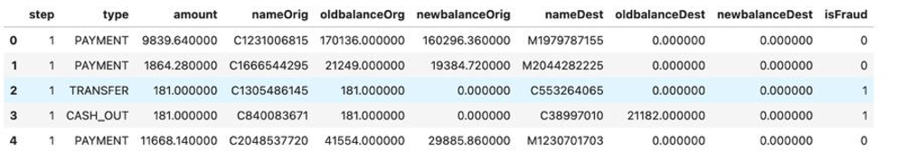

the mean, count , minimum and maximum values of the data are given

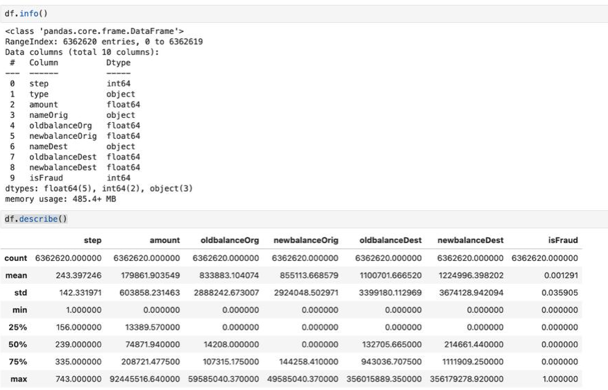

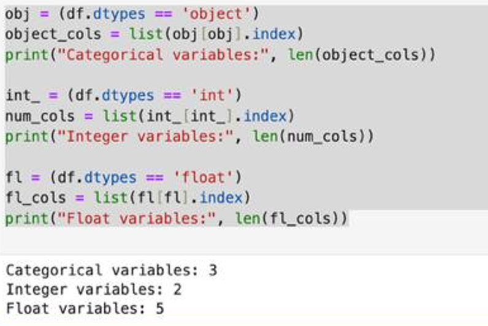